# Snack test 2026

Research Methods and Statistics, demonstration in class on 12 November 2026

Is nationality associated with how you feel about Dutch snacks? 232 of you answered. For each snack, we test H<sub>0</sub> (nationality and opinion are independent) against H<sub>A</sub> (they are dependent), with α = 0.01, chosen before the data came in. Each figure shows the conditional proportions per nationality, and the *X*<sup>2</sup> distribution with the critical value (black arrow) and our *X*<sup>2</sup> (purple arrow).

| Snack | N | *X*<sup>2</sup> | df | p | Decision |
| --- | --- | --- | --- | --- | --- |
| Stroopwafels | 232 | 3.762 | 1 | 0.052 | fail to reject H<sub>0</sub> |
| Drop | 231 | 78.341 | 1 | < 0.001 | reject H<sub>0</sub> |
| Bitterballen | 230 | 16.193 | 1 | < 0.001 | reject H<sub>0</sub> |

### Why only the right tail?

The *X*<sup>2</sup> test is always two-sided. Differences between the observed and the expected counts, in either direction, make *X*<sup>2</sup> larger, which is why only one tail (the right one) is extreme. Based on a significant *X*<sup>2</sup>, we can therefore only make a two-sided conclusion (there is an association, not a “positive” or “negative” one). The conditional proportions then describe how the groups differ in our sample.

## Stroopwafels (N = 232)

### Observed counts

|  | Love | Hate | Total |
| --- | --- | --- | --- |
| Dutch | 114 | 2 | 116 |
| Non-Dutch | 108 | 8 | 116 |
| Total | 222 | 10 | 232 |

### Expected counts if H<sub>0</sub> is true

|  | Love | Hate | Total |
| --- | --- | --- | --- |
| Dutch | 111.000 | 5.000 | 116.000 |
| Non-Dutch | 111.000 | 5.000 | 116.000 |
| Total | 222.000 | 10.000 | 232.000 |

### Conditional proportions

- P(Love | Dutch) = 114/116 = 0.983
- P(Love | Non-Dutch) = 108/116 = 0.931
- Difference = 0.052, relative risk = 0.983 / 0.931 = 1.06

*X*<sup>2</sup> = 3.762, df = 1, p = 0.052

Because p > 0.01, we fail to reject H<sub>0</sub>. There is no evidence for an association between nationality and the opinion on Stroopwafels (absence of evidence).

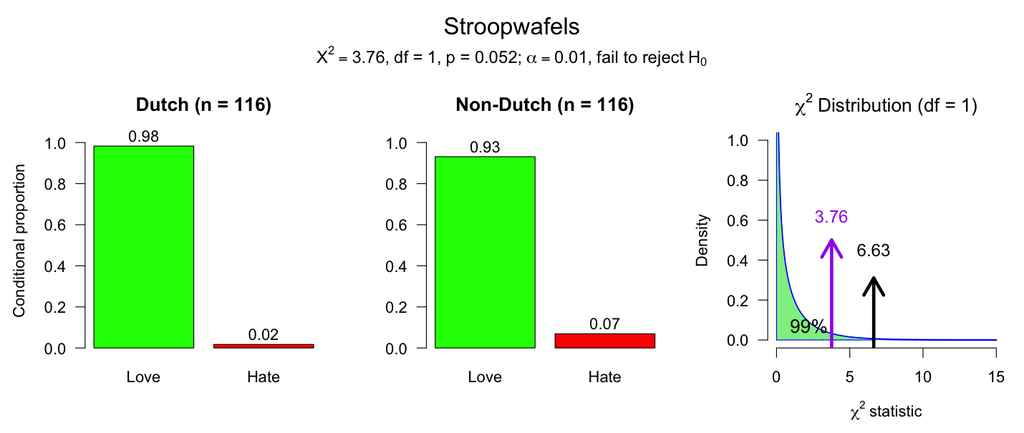

## Drop (N = 231)

### Observed counts

|  | Love | Hate | Total |
| --- | --- | --- | --- |
| Dutch | 83 | 33 | 116 |
| Non-Dutch | 16 | 99 | 115 |
| Total | 99 | 132 | 231 |

### Expected counts if H<sub>0</sub> is true

|  | Love | Hate | Total |
| --- | --- | --- | --- |
| Dutch | 49.714 | 66.286 | 116.000 |
| Non-Dutch | 49.286 | 65.714 | 115.000 |
| Total | 99.000 | 132.000 | 231.000 |

### Conditional proportions

- P(Love | Dutch) = 83/116 = 0.716
- P(Love | Non-Dutch) = 16/115 = 0.139
- Difference = 0.576, relative risk = 0.716 / 0.139 = 5.14

*X*<sup>2</sup> = 78.341, df = 1, p < 0.001

Because p < 0.01, we reject H<sub>0</sub>. There is evidence for an association between nationality and the opinion on Drop.

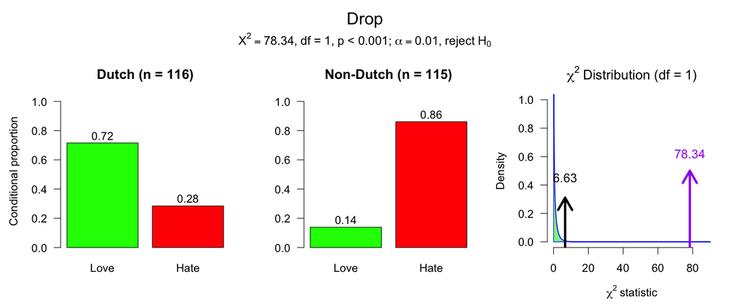

## Bitterballen (N = 230)

### Observed counts

|  | Love | Hate | Total |
| --- | --- | --- | --- |
| Dutch | 107 | 9 | 116 |
| Non-Dutch | 82 | 32 | 114 |
| Total | 189 | 41 | 230 |

### Expected counts if H<sub>0</sub> is true

|  | Love | Hate | Total |
| --- | --- | --- | --- |
| Dutch | 95.322 | 20.678 | 116.000 |
| Non-Dutch | 93.678 | 20.322 | 114.000 |
| Total | 189.000 | 41.000 | 230.000 |

### Conditional proportions

- P(Love | Dutch) = 107/116 = 0.922
- P(Love | Non-Dutch) = 82/114 = 0.719
- Difference = 0.203, relative risk = 0.922 / 0.719 = 1.28

*X*<sup>2</sup> = 16.193, df = 1, p < 0.001

Because p < 0.01, we reject H<sub>0</sub>. There is evidence for an association between nationality and the opinion on Bitterballen.

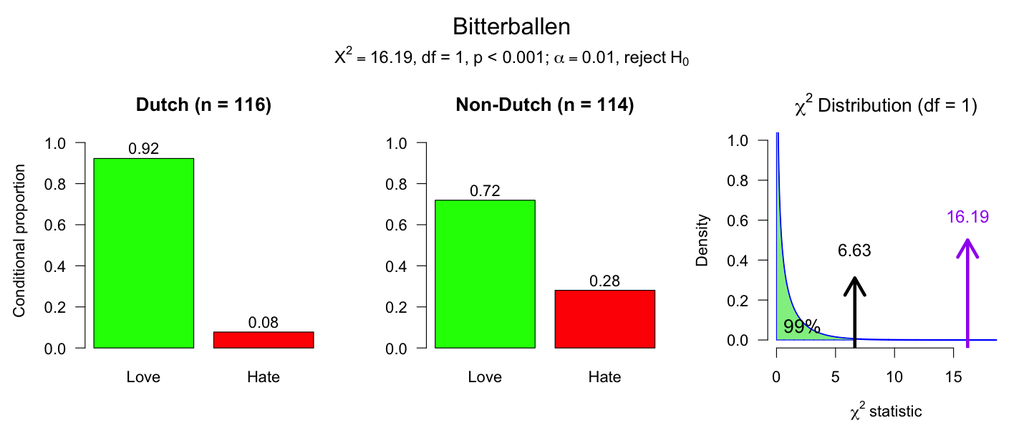